# Gradient Descent

#### Gradient descent is an optimization method to reduce the loss function of the equation

[figure not shown]

#### Lets take a simple example on linear regression problem

We now will see how the gradient descent works in minimising the loss function which is Sum of the squares of the residual

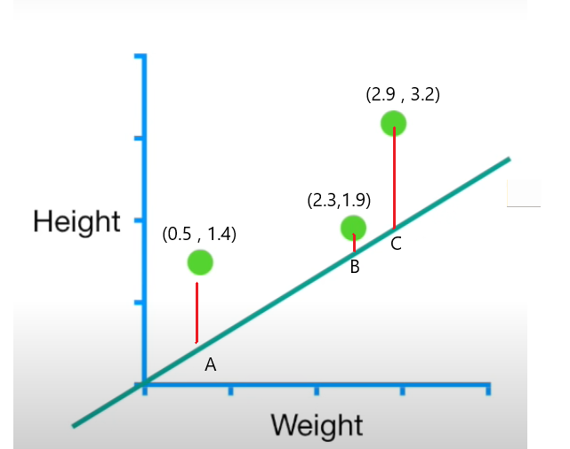

#### Step 1 : calculate the Residual

givren slope = 0.64 ; intercept = 0

point A :

```
weight(x) = 0.5

height(y) = c + mx = 0 + (0.64 X 0.5) = 0.32

residual for point A =  1.4 - 0.32  = 1.08 ~ 1.1
```

likewise we calculate the residual

residual for point B = 0.4

residual for point C = 1.3

#### Sum of Squared residuals = (actual - predicted) = 1.1^2 + 0.4^2 + 1.3^2 = 3.1

plotting on graph we get

[figure not shown]

[figure not shown]

Of the points that we plot , one of the intercept value will have the least value of sum of squared residuals .

We will determine the point using the gradient descent method

sum of the squared residuals = sum of the squared residuals at point(A) + sum of the squared residuals at point(B) + sum of the squared residuals at point(C) = (actual - predicted) at point(A) + (actual - predicted) at point(B) + (actual - predicted) at point(C)

#### Therefore

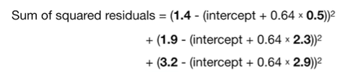

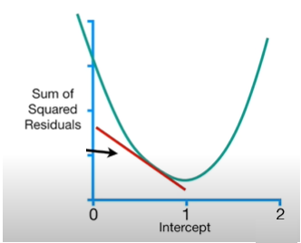

Now we have got the equation of the curve , we can plug in any values to the intercept and calculate the sum of the residuals

by applying the differential using chain rule for point A we get

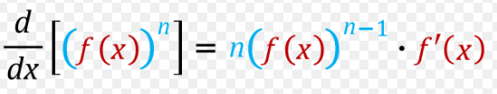

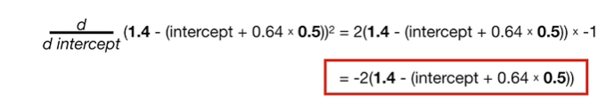

similarly afer finding the derivative for point B and C, we get

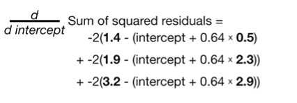

starting form intercept value of zero , we navigate to the curve of minimum slope point by taking series of steps, where our loss function is also minnimum

The step size off the gradient descennt is determined by the slope at particular intercept , and is given by below formula

### Step size = slope X learning rate

the learning rate is a constant say (0.1) through this above equation we take the big and baby steps through the curve

The gradient descent stops taking baby steps when the gradient step size is close to zero.It also stops based on the step size as well

Similarly we can use the gradient descent method with for two or more variables , in below case we found the derivative by keeping intercept and slope as a variable

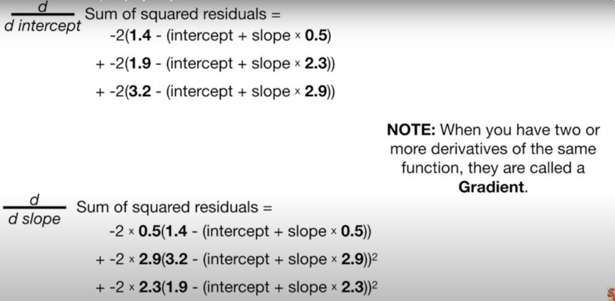

We will use this algorithm to descend to our lowest point in the loss function , which is in our case the sum of squares of residuals

we repeat the steps to minimise the loss fuinction

#### Steps invloved in Gradient descent

1) Take the gradient (derivative) of the loss function with respect to each parameter

2) pick the random values for the parameter

3) plug the parameter values to the gradient

4) Calculate the step size ; step size = slope X learning rate

5) Calculate the new parameter ; new parameter = old parameter - step size

6) Reapea the step 3 to 5 until you get a very small step size or reach the maximum number of steps

```python
from sklearn.linear_model import SGDRegressor
```

```python
SGDRegressor()
#Linear model fitted by minimizing a regularized empirical loss with SGD

#SGD stands for Stochastic Gradient Descent: the gradient of the loss is estimated each sample at a time
#and the model is updated along the way with a decreasing strength schedule (aka learning rate).

#The regularizer is a penalty added to the loss function that shrinks model parameters towards the zero vector using
#either the squared euclidean norm L2 or the absolute norm L1 or a combination of both (Elastic Net). If the
#parameter update crosses the 0.0 value because of the regularizer, the update is truncated to 0.0 to allow for
#learning sparse models and achieve online feature selection.

#This implementation works with data represented as dense numpy arrays of floating point values for the features.
```

```
SGDRegressor(alpha=0.0001, average=False, early_stopping=False, epsilon=0.1,
             eta0=0.01, fit_intercept=True, l1_ratio=0.15,
             learning_rate='invscaling', loss='squared_loss', max_iter=1000,
             n_iter_no_change=5, penalty='l2', power_t=0.25, random_state=None,
             shuffle=True, tol=0.001, validation_fraction=0.1, verbose=0,
             warm_start=False)
```